# Assignment1-Shivam-Billboard Data Wrangling and Visualization

Kumar Shivam

20/10/2021

## Initializing and Exporting the libraries

```r
knitr::opts_chunk$set()
rm(list = ls())
library(tidyverse)
library(ggplot2)
library(kableExtra)
```

## Read the dataset and print first 10 records

The Billboard dataset has been sourced from GitHub. It contains the details when a song frst entered the billboard Top 100. It has columns such as track name, artist name, date entered, genre of the track, length of the song, week, etc. The rank in each week is recorded in 76 columns: x1st.week till x76th.week.

```r
billboard.df = read_csv("Assignment1-Shivam-Billboard-Data-Wrangling-and-Visualization.csv")
kable(head(billboard.df,10),format="html",table.attr="style='width:30%;'") %>%
  kableExtra::kable_styling()
```

| year | artist.inverted | track | time | genre | date.entered | date.peaked | x1st.week | x2nd.week | x3rd.week | x4th.week | x5th.week | x6th.week | x7th.week | x8th.week | x9th.week | x10th.week | x11th.week | x12th.week | x13th.week | x14th.week | x15th.week | x16th.week | x17th.week | x18th.week | x19th.week | x20th.week | x21st.week | x22nd.week | x23rd.week | … |
| --- | --- | --- | --- | --- | --- | --- | --- | --- | --- | --- | --- | --- | --- | --- | --- | --- | --- | --- | --- | --- | --- | --- | --- | --- | --- | --- | --- | --- | --- | --- |
| 2000 | Destiny’s Child | Independent Women Part I | 3:38 | Rock | 2000-09-23 | 2000-11-18 | 78 | 63 | 49 | 33 | 23 | 15 | 7 | 5 | 1 | 1 | 1 | 1 | 1 | 1 | 1 | 1 | 1 | 1 | 1 | 2 | 3 | 7 | 10 | … |
| 2000 | Santana | Maria, Maria | 4:18 | Rock | 2000-02-12 | 2000-04-08 | 15 | 8 | 6 | 5 | 2 | 3 | 2 | 2 | 1 | 1 | 1 | 1 | 1 | 1 | 1 | 1 | 1 | 1 | 8 | 15 | 19 | 21 | 26 | … |
| 2000 | Savage Garden | I Knew I Loved You | 4:07 | Rock | 1999-10-23 | 2000-01-29 | 71 | 48 | 43 | 31 | 20 | 13 | 7 | 6 | 4 | 4 | 4 | 6 | 4 | 2 | 1 | 1 | 1 | 2 | 1 | 2 | 4 | 8 | 8 | … |
| 2000 | Madonna | Music | 3:45 | Rock | 2000-08-12 | 2000-09-16 | 41 | 23 | 18 | 14 | 2 | 1 | 1 | 1 | 1 | 2 | 2 | 2 | 2 | 2 | 4 | 8 | 11 | 16 | 20 | 25 | 27 | 27 | 29 | … |
| 2000 | Aguilera, Christina | Come On Over Baby (All I Want Is You) | 3:38 | Rock | 2000-08-05 | 2000-10-14 | 57 | 47 | 45 | 29 | 23 | 18 | 11 | 9 | 9 | 11 | 1 | 1 | 1 | 1 | 4 | 8 | 12 | 22 | 23 | 43 | 44 | NA | NA | … |
| 2000 | Janet | Doesn’t Really Matter | 4:17 | Rock | 2000-06-17 | 2000-08-26 | 59 | 52 | 43 | 30 | 29 | 22 | 15 | 10 | 10 | 5 | 1 | 1 | 1 | 2 | 2 | 3 | 3 | 7 | 8 | 20 | 25 | 37 | 40 | … |
| 2000 | Destiny’s Child | Say My Name | 4:31 | Rock | 1999-12-25 | 2000-03-18 | 83 | 83 | 44 | 38 | 16 | 13 | 16 | 16 | 16 | 18 | 17 | 14 | 1 | 1 | 1 | 2 | 2 | 3 | 5 | 5 | 5 | 7 | 10 | … |
| 2000 | Iglesias, Enrique | Be With You | 3:36 | Latin | 2000-04-01 | 2000-06-24 | 63 | 45 | 34 | 23 | 17 | 12 | 9 | 8 | 8 | 6 | 5 | 4 | 1 | 1 | 1 | 3 | 11 | 14 | 24 | 28 | NA | NA | NA | … |
| 2000 | Sisqo | Incomplete | 3:52 | Rock | 2000-06-24 | 2000-08-12 | 77 | 66 | 61 | 61 | 61 | 55 | 2 | 1 | 1 | 2 | 2 | 4 | 5 | 5 | 7 | 8 | 10 | 10 | 9 | 14 | 17 | 20 | 25 | … |
| 2000 | Lonestar | Amazed | 4:25 | Country | 1999-06-05 | 2000-03-04 | 81 | 54 | 44 | 39 | 38 | 33 | 29 | 29 | 32 | 27 | 26 | 24 | 27 | 32 | 33 | 35 | 35 | 40 | 43 | 50 | NA | NA | NA | … |

```r
glimpse(billboard.df)
```

```
## Rows: 317
## Columns: 83
## $ year            <dbl> 2000, 2000, 2000, 2000, 2000, 2000, 2000, 2000, 2000, ~
## $ artist.inverted <chr> "Destiny's Child", "Santana", "Savage Garden", "Madonna", "Aguilera, Christina", "Janet", "Destiny's Child", "Iglesias, Enrique", "Sisqo", "Lonestar", "N'Sync", "Aguilera, Christina", "Vertical Horizon", "Creed", "Aaliyah", "matchbox twenty", "Carey, Mariah", "Hill, Faith"…
## $ track           <chr> "Independent Women Part I", "Maria, Maria", "I Knew I ~
## $ time            <chr> "3:38", "4:18", "4:07", "3:45", "3:38", "4:17", "4:31"~
## $ genre           <chr> "Rock", "Rock", "Rock", "Rock", "Rock", "Rock", "Rock"~
## $ date.entered    <date> 2000-09-23, 2000-02-12, 1999-10-23, 2000-08-12, 2000-0~
## $ date.peaked     <date> 2000-11-18, 2000-04-08, 2000-01-29, 2000-09-16, 2000-~
## $ x1st.week       <dbl> 78, 15, 71, 41, 57, 59, 83, 63, 77, 81, 82, 71, 70, 8~
## $ x2nd.week       <dbl> 63, 8, 48, 23, 47, 52, 83, 45, 66, 54, 70, 51, 61, 78,~
## $ x3rd.week       <dbl> 49, 6, 43, 18, 45, 43, 44, 34, 61, 44, 51, 28, 53, 76,~
## $ x4th.week       <dbl> 33, 5, 31, 14, 29, 30, 38, 23, 61, 39, 39, 18, 46, 74,~
## $ x5th.week       <dbl> 23, 2, 20, 2, 23, 29, 16, 17, 61, 38, 26, 13, 40, 70, ~
## $ x6th.week       <dbl> 15, 3, 13, 1, 18, 22, 13, 12, 55, 33, 19, 13, 33, 68, ~
```

[output cut: 70 more lines]

As per the above display of the data, it can be seen that the dataset is not tidy. One variable (i.e., rank) is spread across multiple columns (i.e., week) and hence violates one of the tidy data principles.

## Check for any missing data and empty cells

```r
#Check for any missing data
colSums(is.na(billboard.df))
```

```
##            year artist.inverted           track            time           genre
##               0               0               0               0               0
##    date.entered     date.peaked       x1st.week       x2nd.week       x3rd.week
##               0               0               0               5              10
##       x4th.week       x5th.week       x6th.week       x7th.week       x8th.week
##              17              25              37              48              57
##       x9th.week      x10th.week      x11th.week      x12th.week      x13th.week
##              64              73              81              95             107
##      x14th.week      x15th.week      x16th.week      x17th.week      x18th.week
##             113             120             135             140             151
##      x19th.week      x20th.week      x21st.week      x22nd.week      x23rd.week
##             161             171             252             262             269
##      x24th.week      x25th.week      x26th.week      x27th.week      x28th.week
##             271             279             281             288             293
##      x29th.week      x30th.week      x31st.week      x32nd.week      x33rd.week
##             297             297             298             299             305
##      x34th.week      x35th.week      x36th.week      x37th.week      x38th.week
##             307             308             308             308             309
##      x39th.week      x40th.week      x41st.week      x42nd.week      x43rd.week
##             309             310             310             311             311
##      x44th.week      x45th.week      x46th.week      x47th.week      x48th.week
##             311             312             312             312             313
##      x49th.week      x50th.week      x51st.week      x52nd.week      x53rd.week
##             313             313             313             313             313
##      x54th.week      x55th.week      x56th.week      x57th.week      x58th.week
##             315             315             315             315             315
##      x59th.week      x60th.week      x61st.week      x62nd.week      x63rd.week
##             315             315             315             315             315
##      x64th.week      x65th.week      x66th.week      x67th.week      x68th.week
##             315             316             317             317             317
##      x69th.week      x70th.week      x71st.week      x72nd.week      x73rd.week
##             317             317             317             317             317
##      x74th.week      x75th.week      x76th.week
##             317             317             317
```

```r
#Check for any emptry cells
colSums(billboard.df=='')
```

```
##            year artist.inverted           track            time           genre
##               0               0               0               0               0
##    date.entered     date.peaked       x1st.week       x2nd.week       x3rd.week
##              NA              NA               0              NA              NA
##       x4th.week       x5th.week       x6th.week       x7th.week       x8th.week
##              NA              NA              NA              NA              NA
##       x9th.week      x10th.week      x11th.week      x12th.week      x13th.week
##              NA              NA              NA              NA              NA
##      x14th.week      x15th.week      x16th.week      x17th.week      x18th.week
##              NA              NA              NA              NA              NA
##      x19th.week      x20th.week      x21st.week      x22nd.week      x23rd.week
##              NA              NA              NA              NA              NA
##      x24th.week      x25th.week      x26th.week      x27th.week      x28th.week
##              NA              NA              NA              NA              NA
##      x29th.week      x30th.week      x31st.week      x32nd.week      x33rd.week
##              NA              NA              NA              NA              NA
##      x34th.week      x35th.week      x36th.week      x37th.week      x38th.week
##              NA              NA              NA              NA              NA
##      x39th.week      x40th.week      x41st.week      x42nd.week      x43rd.week
##              NA              NA              NA              NA              NA
##      x44th.week      x45th.week      x46th.week      x47th.week      x48th.week
##              NA              NA              NA              NA              NA
##      x49th.week      x50th.week      x51st.week      x52nd.week      x53rd.week
##              NA              NA              NA              NA              NA
##      x54th.week      x55th.week      x56th.week      x57th.week      x58th.week
##              NA              NA              NA              NA              NA
##      x59th.week      x60th.week      x61st.week      x62nd.week      x63rd.week
##              NA              NA              NA              NA              NA
##      x64th.week      x65th.week      x66th.week      x67th.week      x68th.week
##              NA              NA              NA              NA              NA
##      x69th.week      x70th.week      x71st.week      x72nd.week      x73rd.week
##              NA              NA              NA              NA              NA
##      x74th.week      x75th.week      x76th.week
##              NA              NA              NA
```

## Rename artist.inverted column to artist

```r
billboard1.df <- billboard.df %>%
  rename(artist = artist.inverted)
```

## Tidy the data and print first 10 rows

The data is being tidied using tidyr. We’re not making use of time, date.peaked and x66th.week till x76th.week as these are not required. The columns from x66th.week till x76th.week are having NA values, hence they’re not being used in tidying the data.

```r
billboard2.df <- billboard1.df %>%
    select (-c(time,date.peaked,x66th.week:x76th.week)) %>%
    pivot_longer(
      x1st.week:x65th.week,
      names_to = "week",
      values_to = "rank",
      values_drop_na = TRUE
    )
kable(head(billboard2.df,10),format="html",table.attr="style='width:30%;'") %>%
  kableExtra::kable_styling()
```

| year | artist | track | genre | date.entered | week | rank |
| --- | --- | --- | --- | --- | --- | --- |
| 2000 | Destiny’s Child | Independent Women Part I | Rock | 2000-09-23 | x1st.week | 78 |
| 2000 | Destiny’s Child | Independent Women Part I | Rock | 2000-09-23 | x2nd.week | 63 |
| 2000 | Destiny’s Child | Independent Women Part I | Rock | 2000-09-23 | x3rd.week | 49 |
| 2000 | Destiny’s Child | Independent Women Part I | Rock | 2000-09-23 | x4th.week | 33 |
| 2000 | Destiny’s Child | Independent Women Part I | Rock | 2000-09-23 | x5th.week | 23 |
| 2000 | Destiny’s Child | Independent Women Part I | Rock | 2000-09-23 | x6th.week | 15 |
| 2000 | Destiny’s Child | Independent Women Part I | Rock | 2000-09-23 | x7th.week | 7 |
| 2000 | Destiny’s Child | Independent Women Part I | Rock | 2000-09-23 | x8th.week | 5 |
| 2000 | Destiny’s Child | Independent Women Part I | Rock | 2000-09-23 | x9th.week | 1 |
| 2000 | Destiny’s Child | Independent Women Part I | Rock | 2000-09-23 | x10th.week | 1 |

## Use dplyr to manipulate the data

Create a new column which has the numeric week number instead of string week number

```r
billboard3.df <- billboard2.df %>%
  mutate(
    week = as.integer(gsub("[a-z]*", "", week))
  )
kable(head(billboard3.df,10),format="html",table.attr="style='width:30%;'") %>%
  kableExtra::kable_styling()
```

| year | artist | track | genre | date.entered | week | rank |
| --- | --- | --- | --- | --- | --- | --- |
| 2000 | Destiny’s Child | Independent Women Part I | Rock | 2000-09-23 | 1 | 78 |
| 2000 | Destiny’s Child | Independent Women Part I | Rock | 2000-09-23 | 2 | 63 |
| 2000 | Destiny’s Child | Independent Women Part I | Rock | 2000-09-23 | 3 | 49 |
| 2000 | Destiny’s Child | Independent Women Part I | Rock | 2000-09-23 | 4 | 33 |
| 2000 | Destiny’s Child | Independent Women Part I | Rock | 2000-09-23 | 5 | 23 |
| 2000 | Destiny’s Child | Independent Women Part I | Rock | 2000-09-23 | 6 | 15 |
| 2000 | Destiny’s Child | Independent Women Part I | Rock | 2000-09-23 | 7 | 7 |
| 2000 | Destiny’s Child | Independent Women Part I | Rock | 2000-09-23 | 8 | 5 |
| 2000 | Destiny’s Child | Independent Women Part I | Rock | 2000-09-23 | 9 | 1 |
| 2000 | Destiny’s Child | Independent Women Part I | Rock | 2000-09-23 | 10 | 1 |

The data is tidy now as now we can see the ranking of the tracks week-wise. The rank is now in 1 column instead of being spread across 76 columns.

## Data Visualizations

Before proceeding onto the data visualization, let’s first implement sorting and group_by on the datafframe so that the plotting become easlier.

*Grouping by the dataframe on week and taking out the count of the number of songs, that appeared in top 100 songs:

```r
billboard5.df <- billboard3.df %>%
  group_by(week) %>%
  summarise(n_track=n()) %>%
  arrange(desc(n_track))
```

*Grouping by the dataframe on artist and track (song):

```r
billboard4.df <- billboard3.df %>%
  group_by(artist,track) %>%
  summarise(n_track=n()) %>%
  arrange(desc(n_track))
```

**1) No. of tracks on billboard each week**

Please note, that there could be multiple songs at the same rank, in a week. For example, in week 1, song A and song B can be on rank 50.

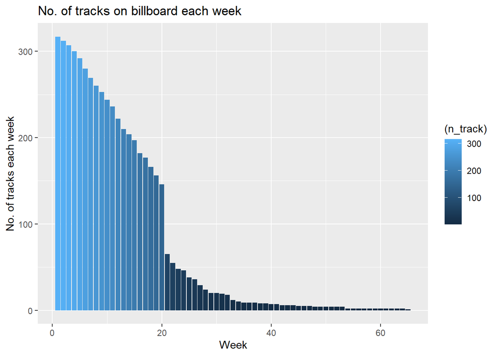

```r
billboard5.df %>%
  ggplot(mapping=aes(y=n_track,x=week,fill=(n_track))) +
  geom_bar(stat = 'identity', position = 'dodge') +
  labs(title = "No. of tracks on billboard each week",
       x = "Week",
       y = "No. of tracks each week")
```

The above plot shows the number of tracks on the billboard for each week. This plot is meaningful as it gives us an insight that the number of tracks decreases as the number of weeks passes by. After week 20, there’s a sudden drop in the number of tracks on the billboard. This means the tracks do well mostly for about 20 weeks.

**2) Top 10 artists with the most number of tracks on the billboard**

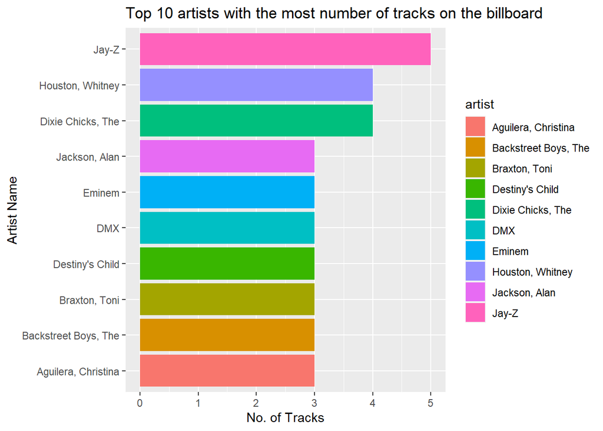

```r
billboard4.df %>%
  distinct(track) %>%
  group_by(artist) %>%
  count() %>%
  ungroup() %>%
  top_n(10, n) %>%
  slice(1:10) %>%
  arrange(desc(n)) %>%
  ggplot(aes(y = fct_reorder(artist, n), x = n, fill = artist)) +
  geom_bar(stat = 'identity', position = 'dodge') +
  labs(title = "Top 10 artists with the most number of tracks on the billboard",
       y = "Artist Name",
       x = "No. of Tracks")
```

The above plot depicts the top 10 artists and the number of their songs which were on the billboard. This shows that the listeners preferred Jay-Z’s songs the most as the artist had 5 songs on the billboard.

**3) Top Eminem Tracks**

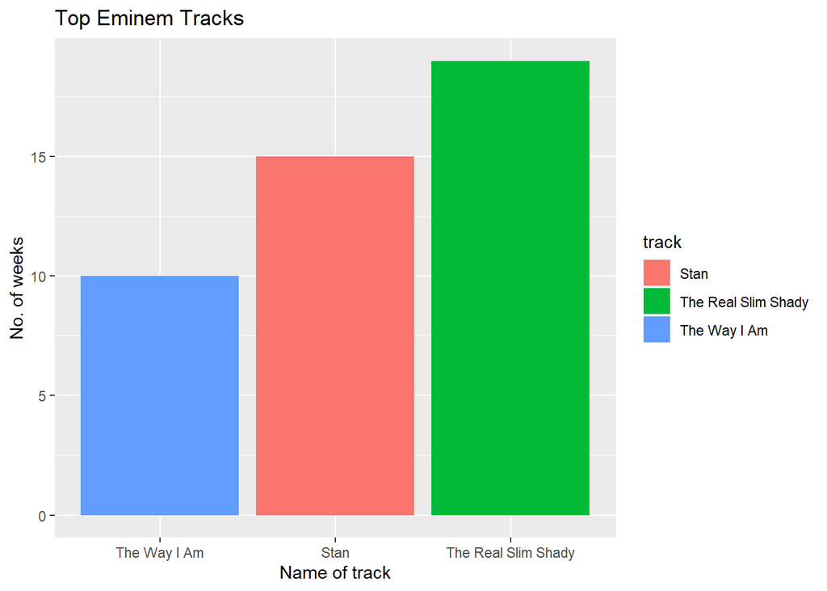

```r
billboard2.df %>%
  filter(artist == "Eminem") %>%
  group_by(track) %>%
  count() %>%
  ggplot(aes(x = fct_reorder(track,n), y = n, fill = track)) +
  geom_bar(stat = 'identity', position = 'dodge') +
  labs(title = "Top Eminem Tracks",
       x = "Name of track",
       y = "No. of weeks")
```

The inference which we can derieve from the above plot is that Eminem had 3 songs on the billboard and the track “The Real Slim Shady” remained on the billboard for over 15 weeks. Out of all his songs, “The Way I Am” track was not liked by many listeners and hence it showed up on the billboard for 10 weeks.